# Untitled

Josh Justison

12/14/2021

## Simulating Phylogenetic Networks

### Does the type of hybridiztion matter?

The different types of hybridization certainly can have different affects on the diversification process by either adding, eliminating, or not changing the number of lineages at each event.

*The expected diversification dynamics can change quite dramatically depending on the hybrid diversification rate. For example, when $s$ is positive then the expected number of extant lineages will often increase quickly and approach infinity in a finite amount of time while the expected number of lineages approaches a constant value when $s$ is negative.

Here we can look at how, when keeping expected diversification dynamics the same, the landscape (in particular the class membership) of networks changes. We will also evaluate how these differences manifest between the complete and reconstructed phylogeny

```r
library(Ternary)
library(tidyr)
library(dplyr)
path<-'../data'



nu_func<-function() 0.2
divs<- c(-0.1,0,0.1) ##this is hybridization diversification

my_frame<-as.data.frame(matrix(NA,nrow = 20000*11*3,ncol=9))
colnames(my_frame)<- c('rets'   ,'tips','level','tree_child','tree_based','fu_stable','recon','nu_neut','s')
frame2<-as.data.frame(matrix(NA,nrow = 10000*11*3,ncol=4))
colnames(frame2)<-c('rets','tips','nu_neut','s')
count<-0
n1<-rep(NA,11*3)
n2<-rep(NA,11*3)
n3<-rep(NA,11*3)
for(s in divs){
  file_name_base<-paste(path,'/s_',as.double(s),'_nu_neut',sep='')
  props<-seq(0,nu_func()-abs(s),length.out=11)


  for(nu_neutral in props){
    file_name<-paste(file_name_base,'/nu_neut_',nu_neutral,'/phydata.csv',sep = '')
    nu_pos <- (nu_func()-nu_neutral+s)/2
    nu_neg <- nu_pos-s

    n1[count+1]<-nu_pos
    n2[count+1]<-nu_neg
    n3[count+1]<-nu_neutral



    dat <- read.csv(file =file_name)[,-1]
    nrows<-nrow(dat)
    frame2$rets[((count*nrows)+1):((count+1)*nrows)]<-dat$rec_rets/dat$rets
    frame2$tips[((count*nrows)+1):((count+1)*nrows)]<-dat$rec_tips/dat$tips
    frame2$s[((count*nrows)+1):((count+1)*nrows)] <-s
    frame2$nu_neut[((count*nrows)+1):((count+1)*nrows)]<-nu_neutral

    to_bind<-dat[,7:12]
    dat<-dat[,-(7:12)]
    colnames(to_bind)<-colnames(dat)
    recon<-c(rep(F,nrows),rep(T,nrows))
    dat<-rbind(dat,to_bind)
    ss<-rep(s,2*nrows)
    nu_neut<-rep(nu_neutral,2*nrows)
    dat<-cbind(dat,recon,nu_neut,ss)

    my_frame[((count*2*nrows)+1):((count+1)*2*nrows),]<-dat
    count<-count+1
  }
}

my_frame$rets[is.nan(my_frame$rets)]<-0
my_frame<-as_tibble(my_frame)

summed<- my_frame %>%
  group_by(s,nu_neut,recon) %>%
  summarize(tc = sum(tree_child)/n(),
            tb = sum(tree_based)/n(),
            fus= sum(fu_stable)/n(),
            ratio = mean(rets/tips),
            tips = mean(tips))
grouped <- summed %>%
  group_by(s,recon)

grouped
```

```
## # A tibble: 66 x 8
## # Groups:   s, recon [6]
##        s nu_neut recon    tc    tb   fus ratio  tips
##    <dbl>   <dbl> <lgl> <dbl> <dbl> <dbl> <dbl> <dbl>
##  1  -0.1    0    FALSE 0.462 0.899 0.610 0.213  25.0
##  2  -0.1    0    TRUE  0.456 0.88  0.612 0.340  12.4
##  3  -0.1    0.01 FALSE 0.463 0.901 0.612 0.214  25.1
##  4  -0.1    0.01 TRUE  0.450 0.879 0.611 0.345  12.5
##  5  -0.1    0.02 FALSE 0.477 0.906 0.623 0.208  24.6
##  6  -0.1    0.02 TRUE  0.466 0.887 0.624 0.336  12.2
##  7  -0.1    0.03 FALSE 0.472 0.914 0.622 0.210  25.1
##  8  -0.1    0.03 TRUE  0.462 0.889 0.614 0.337  12.5
##  9  -0.1    0.04 FALSE 0.475 0.910 0.623 0.211  25.2
## 10  -0.1    0.04 TRUE  0.459 0.886 0.620 0.337  12.6
## # ... with 56 more rows
```

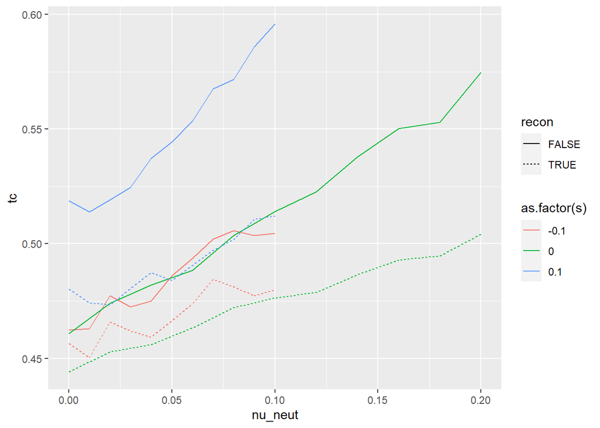

```r
library(ggplot2)

ggplot(grouped,aes(nu_neut,tc,color =as.factor(s),linetype=recon)) + geom_line()
```

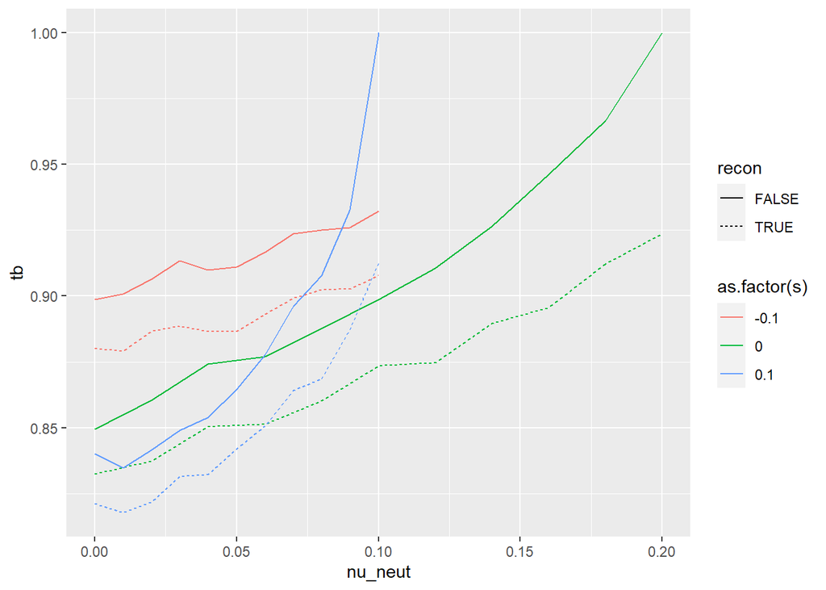

```r
ggplot(grouped,aes(nu_neut,tb,color =as.factor(s),linetype=recon)) + geom_line()
```

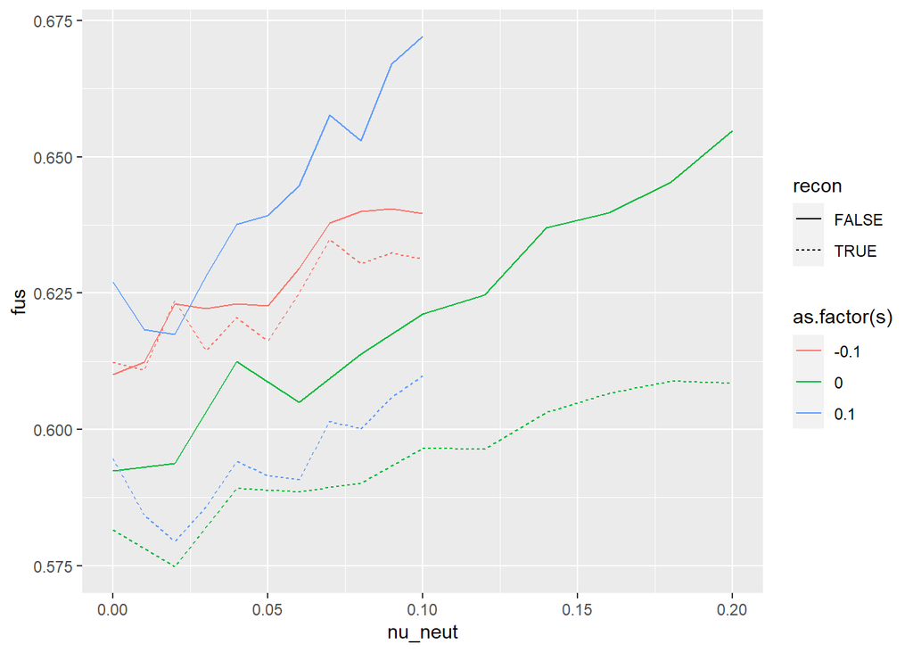

```r
ggplot(grouped,aes(nu_neut,fus,color =as.factor(s),linetype=recon)) + geom_line()
```

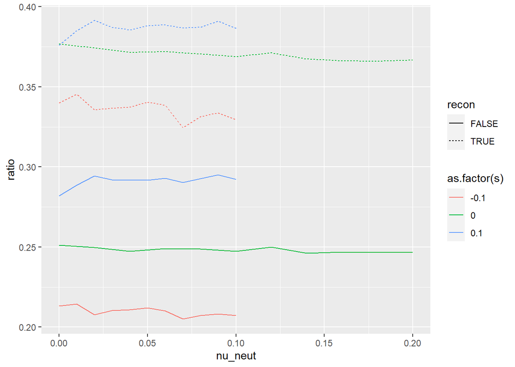

```r
ggplot(grouped,aes(nu_neut,ratio,color =as.factor(s),linetype=recon)) + geom_line()
```

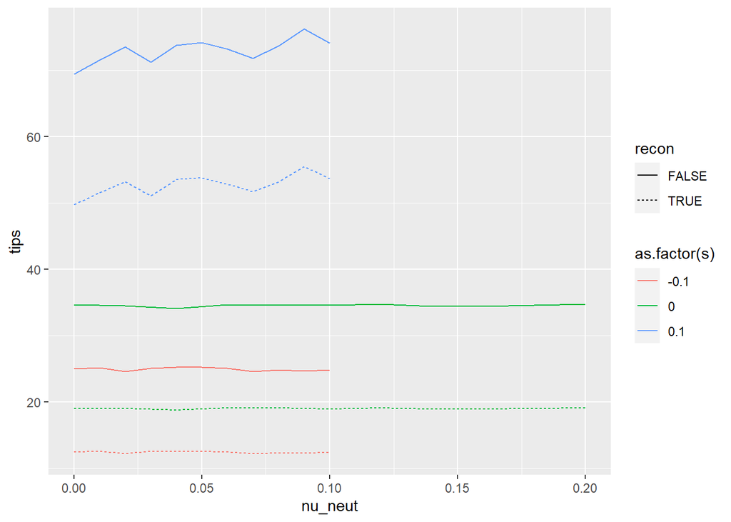

```r
ggplot(grouped,aes(nu_neut,tips,color =as.factor(s),linetype=recon)) + geom_line()
```

```r
frame2$rets[is.nan(frame2$rets)]<-0
group2 <-frame2 %>%
  group_by(s,nu_neut) %>%
  summarize(ret_per= mean(rets),
            tips_per = mean(tips))
group2
```

```
## # A tibble: 33 x 4
## # Groups:   s [3]
##        s nu_neut ret_per tips_per
##    <dbl>   <dbl>   <dbl>    <dbl>
##  1  -0.1    0      0.607    0.471
##  2  -0.1    0.01   0.611    0.470
##  3  -0.1    0.02   0.607    0.468
##  4  -0.1    0.03   0.608    0.473
##  5  -0.1    0.04   0.611    0.471
##  6  -0.1    0.05   0.610    0.471
##  7  -0.1    0.06   0.609    0.472
##  8  -0.1    0.07   0.599    0.471
##  9  -0.1    0.08   0.599    0.467
## 10  -0.1    0.09   0.613    0.472
## # ... with 23 more rows
```

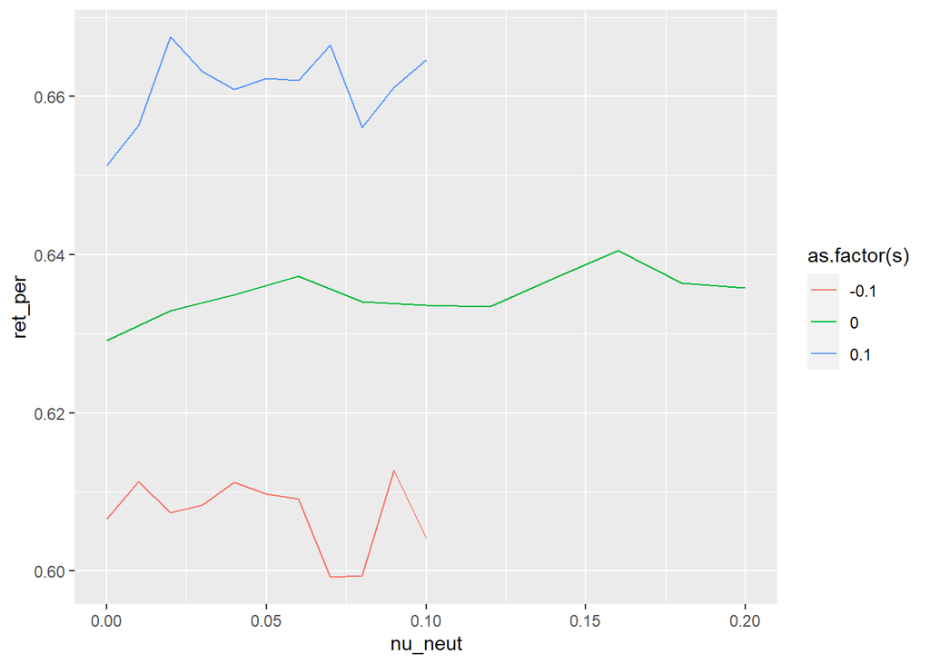

```r
ggplot(group2,aes(nu_neut,ret_per,color=as.factor(s)))+geom_line()
```

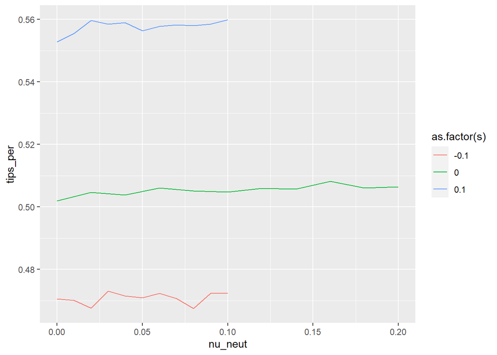

```r
ggplot(group2,aes(nu_neut,tips_per,color=as.factor(s)))+geom_line()
```

```r
ave_N<-function(age,lambda,mu,nu_pos,nu_neg,N0=2){
  r<-lambda-mu
  s<-0.5*(nu_pos-nu_neg)

  val<- (-log(abs(s*(N0*(exp((r-s)*age)-1)+1)-r)))/s
  val2<-(-log(abs(s*(N0*(exp((r-s)*0)-1)+1)-r)))/s
  return(val-val2)
}


N1<-ave_N(1,4,2,0.05,0.15)
N2<-ave_N(1,4,2,0.15,0.05)
N1
```

```
## [1] 5.705707
```

```r
N2
```

```
## [1] 7.397041
```

```r
((N1*(N1-1))/2)*0.15
```

```
## [1] 2.013704
```

```r
((N2*(N2-1))/2)*0.05
```

```
## [1] 1.182979
```

```r
((N1*(N1-1))/2)*0.2
```

```
## [1] 2.684938
```

```r
((N2*(N2-1))/2)*0.2
```

```
## [1] 4.731917
```

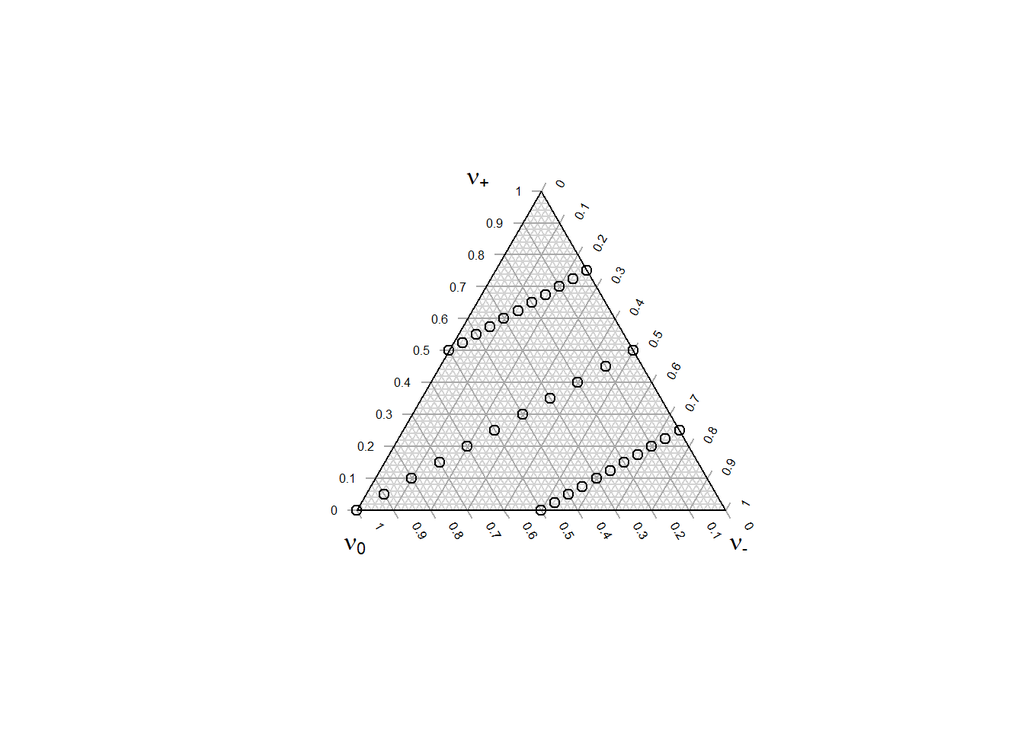

```r
TernaryPlot(atip = expression(nu['+']),
            btip = expression(nu['-']),
            ctip = expression(nu['0']),axis.labels = seq(0,1,by=0.1),axis.cex=0.5
)

dat <- data.frame(n1,
                 n2,
                 n3)
TernaryPoints(dat)
```